# group7_hw5_prob2

```python
import glob
import re
import warnings

# The workhorses
import numpy as np
import pandas as pd

# scikit-learn stuff
import sklearn
import sklearn.cross_validation
import sklearn.linear_model

import scipy

# Plotting modules
import matplotlib.pyplot as plt

# BE/Bi 103 utilities
import sys
sys.path.insert(0, '/Users/chigozie/git/bebi103_utils/')

import bebi103

# Import Bokeh modules for interactive plotting
import bokeh.io
import bokeh.models
import bokeh.plotting

# Display graphics in this notebook
bokeh.io.output_notebook()

# This is to enable inline displays for the purposes of the tutorial
%matplotlib inline

# This enables SVG graphics inline
%config InlineBackend.figure_formats = {'png', 'retina'}

# Seaborn makes plots look nice
import seaborn as sns
sns.set_context('notebook', font_scale=1.5, rc={'lines.linewidth': 2.5})
sns.set_style('darkgrid', {'axes.facecolor': '(0.875, 0.875, 0.9)'})

# Suppress future warnings
warnings.simplefilter(action='ignore', category=FutureWarning)
```

BokehJS successfully loaded.

**a)** Load in the data for one of these FRET efficiency titration curves. You can download the data set here. Compute the background-subtracted fluorescence and the FRET efficiency. *These are real data, graciously donated by Emily Blythe, a student in last year's class. This is from a novel assay, and the identities of the proteins are hidden. If you are interested in the proteins they are studying, please ask me and we can discuss.*

```python
df = pd.read_csv('data/fret_binding_curve.csv', comment='#')
```

```python
df.columns = ['buffer fluorescence', 'total fluorescence', 'c_a', 'c_b']
df.head()
```

|  | buffer fluorescence | total fluorescence | c_a | c_b |
| --- | --- | --- | --- | --- |
| 0 | 1256.5751 | 258316.2818 | 50 | 1500.00 |
| 1 | 1256.5751 | 267722.6277 | 50 | 750.00 |
| 2 | 1256.5751 | 267431.6620 | 50 | 375.00 |
| 3 | 1256.5751 | 284596.2914 | 50 | 187.50 |
| 4 | 1256.5751 | 254903.3958 | 50 | 93.75 |

```python
df['F'] = df['total fluorescence'] - df['buffer fluorescence']
```

```python
df.head()
```

|  | buffer fluorescence | total fluorescence | c_a | c_b | F |
| --- | --- | --- | --- | --- | --- |
| 0 | 1256.5751 | 258316.2818 | 50 | 1500.00 | 257059.7067 |
| 1 | 1256.5751 | 267722.6277 | 50 | 750.00 | 266466.0526 |
| 2 | 1256.5751 | 267431.6620 | 50 | 375.00 | 266175.0869 |
| 3 | 1256.5751 | 284596.2914 | 50 | 187.50 | 283339.7163 |
| 4 | 1256.5751 | 254903.3958 | 50 | 93.75 | 253646.8207 |

The FRET efficiency is proportional to the fraction of a that is bound, or

\begin{align} e = \alpha \, \frac{c_{ab}}{c_a^0} = \frac{2\alpha\,c_b^0}{K_d+c_a^0+c_b^0 + \sqrt{\left(K_d+c_a^0+c_b^0\right)^2 - 4c_a^0\,c_b^0}}, \end{align}

```python
F_0 = df[df['c_b']==0]['F'].mean()
df['e'] = 1 - (df['F'] / F_0)
df.head()
```

|  | buffer fluorescence | total fluorescence | c_a | c_b | F | e |
| --- | --- | --- | --- | --- | --- | --- |
| 0 | 1256.5751 | 258316.2818 | 50 | 1500.00 | 257059.7067 | 0.410066 |
| 1 | 1256.5751 | 267722.6277 | 50 | 750.00 | 266466.0526 | 0.388479 |
| 2 | 1256.5751 | 267431.6620 | 50 | 375.00 | 266175.0869 | 0.389147 |
| 3 | 1256.5751 | 284596.2914 | 50 | 187.50 | 283339.7163 | 0.349756 |
| 4 | 1256.5751 | 254903.3958 | 50 | 93.75 | 253646.8207 | 0.417899 |

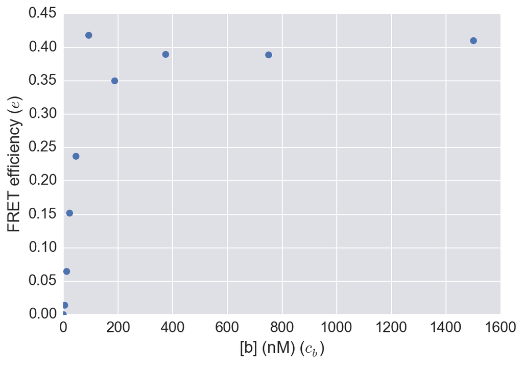

```python
# Take a look at the data
plt.plot(df['c_b'], df['e'], 'o')
plt.xlabel('[b] (nM) ($c_b$)')
plt.ylabel('FRET efficiency ($e$)')
```

**b)** Perform regressions to find $K_d$ with and without an outlier detection scheme. How do the results differ?

\begin{align} c_{ab} = \frac{2c_a^0\,c_b^0}{K_d+c_a^0+c_b^0 + \sqrt{\left(K_d+c_a^0+c_b^0\right)^2 - 4c_a^0\,c_b^0}}. \end{align}

```python
#Model
def fret_efficiency(alpha, c_a_0, c_b_0, K_d):
    c_ab = c_ab_func(c_a_0, c_b_0, K_d)
    return alpha*c_ab/c_a_0

def c_ab_func(c_a_0, c_b_0, K_d):
    numerator = 2 * c_a_0 * c_b_0
    denominator = K_d + c_a_0 + c_b_0 + \
                  np.sqrt((K_d + c_a_0 + c_b_0)**2 - 4 * c_a_0 * c_b_0)
    return numerator / denominator
```

```python
fret_efficiency(0.5,1,1,0.5)
```

```
0.25
```

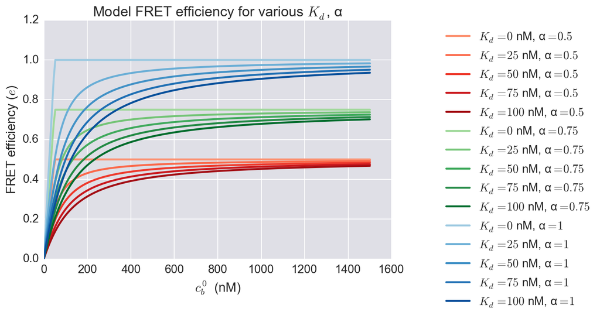

```python
# Values of alpha to consider
alpha = np.linspace(0.5,1,3)

# Values of K_d to consider, units of nanomolar (nM)
K_d = np.linspace(0, 100, 5)

# Fixed a concentration, units of nanomolar (nM)
c_a_0 = 50

# Varied b concentration for plotting (nM)
c_b_0 = np.linspace(0.0, 1500.0, 200)

# Make curves and plot
hues = ['Reds', 'Greens', 'Blues']
for k in range(len(alpha)):
    colors = sns.color_palette(hues[k], len(K_d)+2)
    for i in range(len(K_d)):
        # Compute c_ab over the values of c_a_0.
        e = np.empty_like(c_b_0)
        for j in range(len(c_b_0)):
            e[j] = fret_efficiency(alpha[k], c_a_0, c_b_0[j], K_d[i])

        # Make plot
        label = u'$K_d = %g$ nM, α$ = %g$' % (K_d[i], alpha[k])
        plt.plot(c_b_0, e, '-', color=colors[i+2], label=label)
        plt.xlabel(u'$c_b^0$ (nM)')
        plt.ylabel(u'FRET efficiency ($e$)')
        plt.legend(bbox_to_anchor=(1.6, 1))
        plt.title(u'Model FRET efficiency for various $K_d$, α')
```

These plots look as expected.

$\alpha = \lim_{c_b^0\to\infty} e$, so increasing $\alpha$ increases the plateau.

$K_d = \frac{c_a c_b}{c_ab}$, so increasing $K_d$ decreases the proportion of bound protein for any given initial concentration of b, which decreases the overall FRET efficiency for any given initial concentration of b, which makes the curve less steep.

Now we run a regression. First state Bayes' theorem:

\begin{align} \text{P}(K_d, \alpha \mid e, I) = \frac{\text{P}(e \mid K_d, \alpha, I) \text{P}(K_d, \alpha \mid I)}{\text{P}(e \mid I)} \end{align}

Prior: We assume independence of $K_d$ and $\alpha$. We use a Jeffreys prior for both, as both range between 0 and $\infty$. \begin{align} \text{P}(K_d, \alpha \mid I) &= \text{P}(K_d \mid I)\text{P}(\alpha \mid I) & \text{assuming independence}\ &= \frac{1}{K_d \alpha}\ \end{align}

```python
def resid(p, c_a_0, c_b_0, e):
    """
    Residuals for FRET efficiency model.
    """
    # Unpack parameters
    alpha, K_d = p[:2]

    # Theoretical anisotropy
    e_theor = fret_efficiency(alpha, c_a_0, c_b_0, K_d)
    return e - e_theor

def log_post(p, c_a_0, c_b_0, e):
    """
    Compute log of posterior for single set of parameters.
    p[0] = alpha
    p[1] = K_d
    p[2] = sigma^2
    """
    # Unpack parameters
    alpha, K_d, variance = p

    # Residuals
    residual = resid(p, c_a_0, c_b_0, e)
    #print(residual)

    if (K_d <= 0) | (alpha <= 0) | (variance <= 0):
        return -np.inf
    else:
#         print(p)
        log_posterior=np.log(1/(K_d*alpha)) + \
                      np.log(1/np.sqrt(2*np.pi*(variance))) - \
                      np.sum((residual)**2)/(2*(variance))
#         print(log_posterior)
        return log_posterior

def neg_log_post(p, c_a_0, c_b_0, e):
    return -log_post(p, c_a_0, c_b_0, e)
```

Fit using residuals

```python
fit_curve = pd.DataFrame(scipy.optimize.leastsq(resid, [0.5, 1, 1], args=(50, df['c_b'],
            df['e']))[0])

fit_curve = fit_curve.transpose()
fit_curve.columns = ('alpha', 'K_d', 'variance')
fit_curve
```

|  | alpha | K_d | variance |
| --- | --- | --- | --- |
| 0 | 0.400163 | 6.652677 | 1 |

Fit using whole posterior, so we get variance as well.

```python
fit_curve_minimize = scipy.optimize.minimize(neg_log_post, [0.4, 6, 1], args=(50, df['c_b'],
            df['e']))
# fit_curve_minimize = pd.DataFrame(fit_curve_minimize['x'])
# fit_curve_minimize = fit_curve_minimize.transpose()
# fit_curve_minimize.columns = ('alpha', 'K_d', 'variance')
fit_curve_minimize
```

```
      fun: 1.7981386795824115
      jac: array([ 2.51002108,  0.16658533,  0.49626859])
  message: 'Desired error not necessarily achieved due to precision loss.'
  success: False
      nit: 0
     nfev: 183
   status: 2
 hess_inv: array([[1, 0, 0],
       [0, 1, 0],
       [0, 0, 1]])
        x: array([ 0.4,  6. ,  1. ])
     njev: 35
```

```python
scipy.optimize.minimize?
```

Why am I not getting good results for this fit? I can't see a problem with my neg_log_post function.

```python
# resid(p, c_a_0, c_b_0, e):
# alpha, K_d, variance = p
neg_log_post([0.40, 6, 0.01], 50, df['c_b'], df['e'])
```

[output not shown]

```
-0.13503692005160778
```

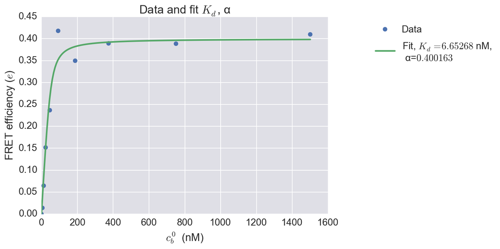

```python
# Data
plt.plot(df['c_b'], df['e'], 'o', label='Data')

# Fit
# Values of alpha to consider
alpha = fit_curve['alpha'].values[0]

# Values of K_d to consider, units of nanomolar (nM)
K_d = fit_curve['K_d'].values[0]

# Fixed a concentration, units of nanomolar (nM)
c_a_0 = 50

# Varied b concentration for plotting (nM)
c_b_0 = np.linspace(0.0, 1500.0, 200)

# Make curve and plot
e = np.empty_like(c_b_0)
for j in range(len(c_b_0)):
    e[j] = fret_efficiency(alpha, c_a_0, c_b_0[j], K_d)

# Make plot
_ = plt.plot(c_b_0, e, '-', label=u'Fit, $K_d = %g$ nM,\n α=$%g$' % (K_d, alpha))
_ = plt.xlabel(u'$c_b^0$ (nM)')
_ = plt.ylabel(u'FRET efficiency ($e$)')
_ = plt.legend(bbox_to_anchor=(1.6, 1))
_ = plt.title(u'Data and fit $K_d$, α')
```

Now we want to try to detect outliers. Let's use the good-and-bad data method from Tutorial 5b.

We need a new posterior for good/bad data model:

```python
def log_post_good_bad(p, c_a_0, c_b_0, e):
    """
    Compute log of posterior for single set of parameters.
    p[0] = alpha
    p[1] = K_d
    p[2] = sigma^2
    p[3] = sigma_bad^2
    """
    # Unpack parameters
    alpha, K_d, variance, variance_bad = p[:5]
    g = p[5:]

    #Residuals
    residual = resid(p, c_a_0, c_b_0, e)
    #print(residual)

    if (K_d <= 0) | (alpha <= 0) | (variance <= 0) | (variance_bad <= 0) | (g < 0.0).any() | (g > 1.0).any():
        return -np.inf
    else:
        sigma = np.sqrt(variance)
        sigma_bad = np.sqrt(variance_bad)
        log_prior = -np.log(sigma) - np.log(sigma_bad)

        mu = fret_efficiency(alpha, c_a_0, c_b_0, K_d)

        # Add in likelihood
        log_like_good = np.log(g / sigma) - ((x - mu) / sigma)**2 / 2.0
        log_like_bad = np.log((1.0 - g) / sigma_bad) \
                        - ((x - mu) / sigma_bad)**2 / 2.0
        log_like = np.logaddexp(log_like_good, log_like_bad).sum()

        # Return whole posterior
        return log_prior + log_like

def neg_log_post_good_bad(p, c_a_0, c_b_0, e):
    return -log_post_good_bad(p, c_a_0, c_b_0, e)
```

```python
fit_curve_minimize = scipy.optimize.minimize(neg_log_post_good_bad, [0.4, 6, 1,0], args=(50, df['c_b'],
            df['e']))
# fit_curve_minimize = pd.DataFrame(fit_curve_minimize['x'])
# fit_curve_minimize = fit_curve_minimize.transpose()
# fit_curve_minimize.columns = ('alpha', 'K_d', 'variance')
fit_curve_minimize
```

[output not shown]

[output cut: 9 more lines]

[output not shown]

As you can see, I didn't get this to work. I expect that, had I successfully implemented outlier detection, the point at (93.75,0.417899) would have been flagged as an outlier, and the fit would have given a greater K_d and an essentially unchanged alpha, resulting in a better fit for the remaining points.